# Homework 3

Data Science at StratCom, Spring 2019

Due on Mar 6, 2019

1. Which plot do we generate to display relationship between
   1. Two quantitative variables `scatter plot`
   2. One quantitative and Categorical variable `side by side box plot`
   3. Two categorical variable `mogaic plot`
   4. One categorical vs many variables (regardless of type) `parallel coordinate plot`
2. We have three variables X, Y, Z of which Y is response variable. What plot will show a two way interaction effect of X and Z on Y if
   1. one of them are quantitative and the other is categorical `scatter plot colored by categorical variable`
   2. both of them are categorical `side by side boxplot for one category colored by other category`
   3. both of them are quantitative `scatter plot with ponys size based on other quantitative variable`

```r
library(ggplot2)
set.seed(352)
x <- rpois(n=100, lambda=20)
z <- rgamma(n=100, shape=2, rate=.5)
y <- 2 + 3*x + 2.5*z + 2*x*z + rnorm(n=100)
iDat <- data.frame(x,y,z)
head(iDat)
```

```
##    x         y          z
## 1 22  97.00124  0.6434923
## 2 33 918.78771 11.9470779
## 3 10  64.86373  1.4508195
## 4 12  92.71791  2.0537968
## 5 21 357.87762  6.5757906
## 6 35 748.26825  8.8399038
```

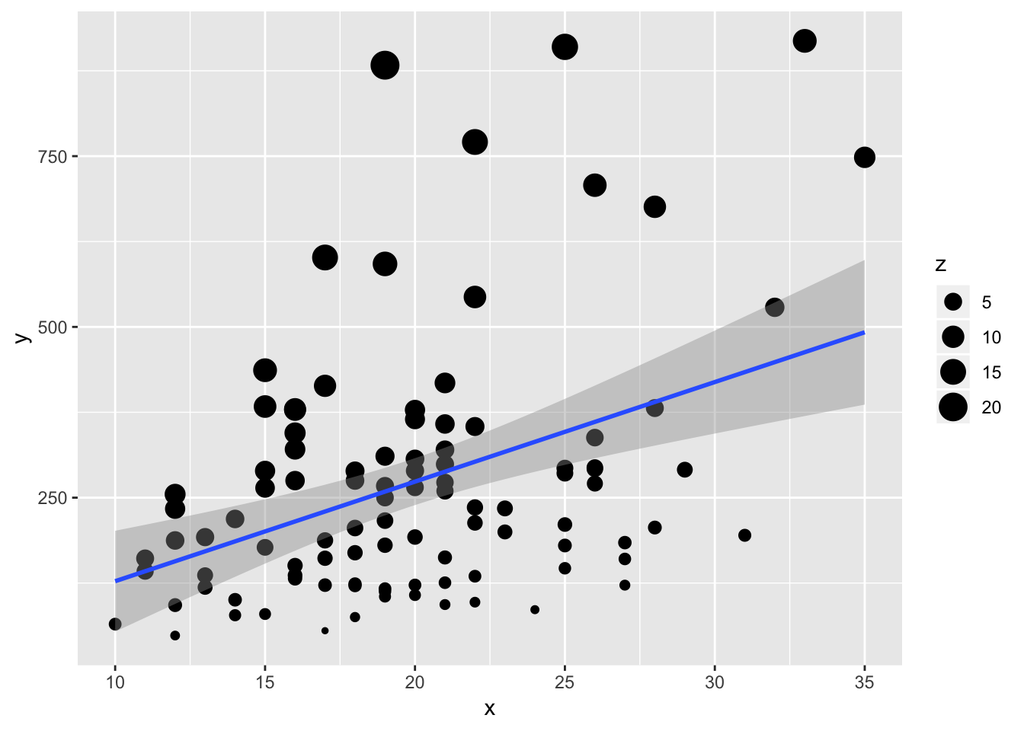

```r
ggplot(iDat, aes(x,y)) + geom_point(aes(size=z))+
  geom_smooth(method = "lm")
```

```r
library(reshape2)
head(french_fries)
```

```
##    time treatment subject rep potato buttery grassy rancid painty
## 61    1         1       3   1    2.9     0.0    0.0    0.0    5.5
## 25    1         1       3   2   14.0     0.0    0.0    1.1    0.0
## 62    1         1      10   1   11.0     6.4    0.0    0.0    0.0
## 26    1         1      10   2    9.9     5.9    2.9    2.2    0.0
## 63    1         1      15   1    1.2     0.1    0.0    1.1    5.1
## 27    1         1      15   2    8.8     3.0    3.6    1.5    2.3
```

# Solution

First we melt the data

```r
melted_fries <- melt(french_fries, id =c("time",     "treatment", "subject",   "rep"))
head(melted_fries)
```

```
##   time treatment subject rep variable value
## 1    1         1       3   1   potato   2.9
## 2    1         1       3   2   potato  14.0
## 3    1         1      10   1   potato  11.0
## 4    1         1      10   2   potato   9.9
## 5    1         1      15   1   potato   1.2
## 6    1         1      15   2   potato   8.8
```

Now cast the data using time to come to column

```r
casted_fries <- dcast(melted_fries, treatment+ subject + rep + variable ~time)
# update the column names
colnames(casted_fries) <- c("treatment", "subject",   "rep", "sensor", paste0("time", 1:10))
head(casted_fries)
```

```
##   treatment subject rep  sensor time1 time2 time3 time4 time5 time6 time7
## 1         1       3   1  potato   2.9   9.0  11.8  13.6  14.0   0.4   2.9
## 2         1       3   1 buttery   0.0   0.3   0.2   0.1   0.3   1.2   0.0
## 3         1       3   1  grassy   0.0   0.1   0.0   0.0   0.0   0.0   0.0
## 4         1       3   1  rancid   0.0   5.8   6.0   1.7   0.0   0.0   0.0
## 5         1       3   1  painty   5.5   0.3   0.0   0.0   1.7   9.5   5.5
## 6         1       3   2  potato  14.0   5.5   7.8   5.3  12.9   3.3   0.8
##   time8 time9 time10
## 1   3.5   1.1     NA
## 2   0.5   0.4     NA
## 3   1.3   0.0     NA
## 4   0.0   0.0     NA
## 5   3.8   7.0     NA
## 6   0.6   2.5     NA
```

Finally plot the data

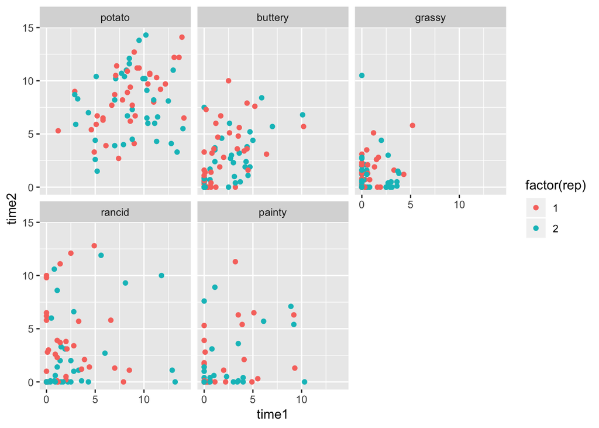

```r
ggplot(casted_fries) + geom_point(aes(time1, time2, color=factor(rep))) +
  facet_wrap(~sensor)
```